# Project: User Value Segmentation (The 6-Tier "Precious Metals" Model)

## 1. Problem Statement

**Objective:** We want to segment our users to deeply understand their spending behavior and deploy targeted strategies to maximize their lifetime value.

**The Challenge:**

- **The "Average" Fallacy:** A simple average spending metric fails because our data follows a **Power Law** (80/20 rule). A small number of top spenders skew the mean, making "average" strategies ineffective.
- **Labeling Bias:** Not all high spenders are "Resellers." We need a neutral, value-based hierarchy that respects all user types (from casual buyers to power users).
- **Operational Inefficiency:** We currently lack a data-driven way to allocate resources—spending too much time on low-value users while under-serving our VIPs.

## 2. The Methodology: Hybrid Statistical Split

To solve this, we utilize a **Hybrid Box-Cox & Head/Tail Breaks** model to identify 6 natural tiers of user value.

- **Box-Cox Transformation:** Normalizes the skewed spending data into a bell curve to find statistical outliers.
- **Recursive Breaks:** Identifies the "fractal" nature of spending, isolating the top 1% of the top 1%.

## 3. The 6-Tier Value Split

Our analysis identifies **6 distinct user tiers** based on Daily Average NMV:

| Tier | Segment Name | Spend Threshold ($) | The Persona (Behavior) |
| --- | --- | --- | --- |
| **6** | **Platinum** | **>$937** | **Top Spenders.** High volume, high frequency. The economic engines of the platform. |
| **5** | **Gold** | **$288 - $937** | **Very High Spenders.** Consistent, professional-level volume. |
| **4** | **Silver** | **$66 - $288** | **Above-Average.** Serious active users with significant monthly spend. |
| **3** | **Bronze** | **$19 - $66** | **Average.** Regular active users, the "Middle Class" of the platform. |
| **2** | **Copper** | **$3 - $19** | **Below-Average.** Occasional buyers or low-value sellers. |
| **1** | **Starter** | **<$3** | **Lowest Spenders.** Low frequency, testing, or dormant. |

## 4. Strategic Goals

We will map these segments to three core strategic pillars:

- **Strategy X: Retention (Platinum & Gold)**
  - *Goal:* 0% Churn.
  - *Action:* White-glove account management, priority support, exclusivity.
- **Strategy Y: Growth (Silver & Bronze)**
  - *Goal:* Ascension. Move them up the metal ladder.
  - *Action:* Value-based incentives ("Reach Silver Status"), loyalty rewards.
- **Strategy Z: Efficiency (Copper & Starter)**
  - *Goal:* Automation. Minimize cost-to-serve.
  - *Action:* Self-service help center, automated nurture campaigns.

#### PART 2: IMPORTS & CONFIGURATION

```python
# 1. Core Data Libraries
import pandas as pd
import numpy as np
import matplotlib.pyplot as plt
# 2. Statistical Libraries
from scipy import stats         # For Box-Cox Transformation & Skewness analysis

# 3. Visualization Libraries
import matplotlib.pyplot as plt # For creating the charts
import seaborn as sns           # For styling the charts to look professional

# 4. Configuration Settings
# Set a clean visual style for all charts
sns.set_style("whitegrid")
plt.rcParams['figure.figsize'] = (12, 6)
plt.rcParams['font.size'] = 12

# Suppress warnings for cleaner output
import warnings
warnings.filterwarnings('ignore')

print("✅ Setup Complete: All libraries loaded and configured.")
```

```
✅ Setup Complete: All libraries loaded and configured.
```

## 3. Data Loading & Preprocessing

In this section, we load the raw user data and prepare it for statistical analysis.

- **Input:** `Reseller Split.xlsx` (Contains User IDs, Day Avg NMV, Total NMV).
- **Cleaning:** We remove any users with 0 or negative spend. The Box-Cox transformation requires strictly positive values ($x > 0$).

```python
# 1. Load Data
df = pd.read_excel('Reseller Split.xlsx')

# 2. Inspect the raw data
print(f"Original Data Size: {df.shape[0]:,} users")

# 3. Apply the "Positive Value" Filter
# Box-Cox and Log functions will fail on 0 or negative numbers.
# We keep only users who have actually spent money.
df_clean = df[df['DAY_AVG_NMV'] > 0].copy()

# 4. Report on Data Quality
removed_count = df.shape[0] - df_clean.shape[0]
print(f"Cleaned Data Size:  {df_clean.shape[0]:,} users")
print(f"Removed:            {removed_count} users (Zero/Negative Spend)")

# 5. Preview the first few rows to verify
print("\nData Preview:")
display(df_clean.head())
```

```
Original Data Size: 85,099 users
Cleaned Data Size:  85,098 users
Removed:            1 users (Zero/Negative Spend)

Data Preview:
```

|  | Random | DAY_AVG_NMV | NMVRETAIL | TOTAL_NMV | UNIQUE_DAYS |
| --- | --- | --- | --- | --- | --- |
| 0 | 857379 | 94.147989 | 94.147989 | 4.707399e+02 | 5 |
| 1 | 778919 | 6516.441627 | 6516.441627 | 2.033130e+06 | 312 |
| 2 | 8035460 | 1.090000 | 1.090000 | 6.540000e+00 | 6 |
| 3 | 1679241 | 790.804968 | 790.804968 | 7.908050e+03 | 10 |
| 4 | 6585274 | 1.931972 | 1.931972 | 1.931972e+00 | 1 |

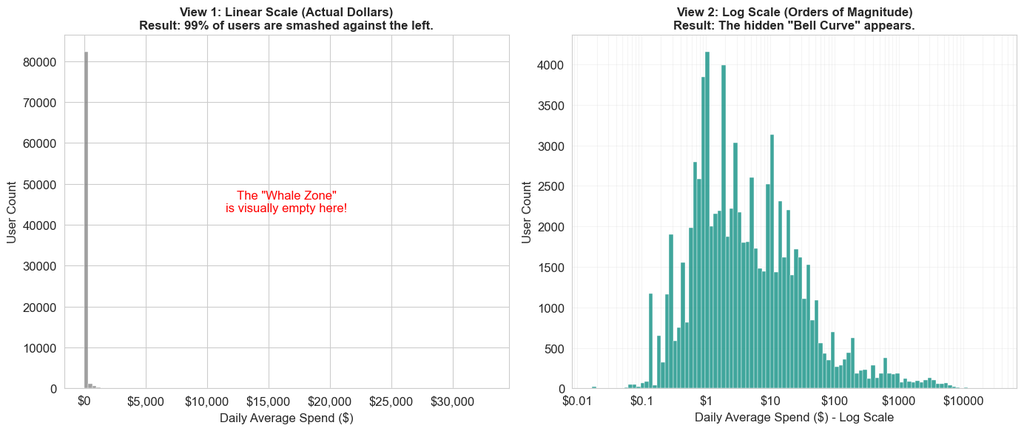

```
Skewness Score: 25.33
⚠️ Verdict: Data is EXTREMELY skewed. Standard averages will fail.
```

```python
# ==========================================
# PART 3b: DATA DIAGNOSIS (Visual Proof)
# ==========================================

import matplotlib.ticker as ticker

# 1. Setup the figure
fig, axes = plt.subplots(1, 2, figsize=(14, 6))

# 2. Define a Currency Formatter (e.g., converts 1000 to $1,000)
def currency_fmt(x, pos):
    if x >= 1_000_000:
        return f'${x*1e-6:.1f}M'
    elif x >= 1_000:
        return f'${x:,.0f}'
    return f'${x:.0f}'

formatter = ticker.FuncFormatter(currency_fmt)

# 3. Chart 1: The Linear Scale (Actual Dollars)
sns.histplot(df_clean['DAY_AVG_NMV'], bins=100, color='gray', ax=axes[0])
axes[0].set_title('View 1: Linear Scale (Actual Dollars)\nResult: 99% of users are smashed against the left.', fontsize=12, fontweight='bold')
axes[0].set_xlabel('Daily Average Spend ($)')
axes[0].set_ylabel('User Count')
# Apply the Dollar Formatter to the X-Axis
axes[0].xaxis.set_major_formatter(formatter)

# Add annotation pointing to the empty space
axes[0].text(df_clean['DAY_AVG_NMV'].max()*0.5, axes[0].get_ylim()[1]*0.5,
             'The "Whale Zone"\nis visually empty here!', fontsize=12, color='red', ha='center')

# 4. Chart 2: The Log Scale (The "Truth")
sns.histplot(df_clean['DAY_AVG_NMV'], log_scale=True, bins=100, color='#00897B', ax=axes[1])
axes[1].set_title('View 2: Log Scale (Orders of Magnitude)\nResult: The hidden "Bell Curve" appears.', fontsize=12, fontweight='bold')
axes[1].set_xlabel('Daily Average Spend ($) - Log Scale')
axes[1].set_ylabel('User Count')

# Apply Dollar Formatter to Log Axis (1, 10, 100, 1000)
axes[1].xaxis.set_major_formatter(ticker.FuncFormatter(lambda y, _: '${:g}'.format(y)))
axes[1].grid(True, which="both", ls="-", alpha=0.2)

plt.tight_layout()
plt.show()

# 5. The Verdict
skew_score = df_clean['DAY_AVG_NMV'].skew()
print(f"Skewness Score: {skew_score:.2f}")
if skew_score > 1:
    print("⚠️ Verdict: Data is EXTREMELY skewed. Standard averages will fail.")
```